# ESM 204: Homework 2

Simulating a Carbon Market

Anthony Luna, Kazia Mermel, & Keene Morrow

4/27/2020

### 1.

Various models were explored for each sector. The model with the best fit was selected by comparing R^2 and AIC values for each model, as appropriate.

#### Sector A

*Linear model equation:*

mc = 0.51 * abatement + 1.66

#### Sector B

*Logistic model equation:*

mc = 58.19 /(1 + 10.56 * exp(- 0.05 * abatement)

#### Sector C

*Piecewise linear model equation:*

From 0 to 39.42: mc = 0

From 39.42 to infinity: mc = 1.39 * abatement - 54.8

#### Sector D

*Logistic model equation:*

mc = 112.29/(1 + 68.1 * exp(- 0.04 * abatement)

#### Demand Curves

The above functions were used to calculate values for demand in a range of possible levels of abatement/pollution from 0 to 300 tons of carbon. These values were then plotted in Figure 1.

### 2.

#### Supply Curves

The above functions were used to calculate values for supply in a range of possible levels of abatement/pollution from 0 to 300 tons of carbon. These values were then plotted in Figure 1.

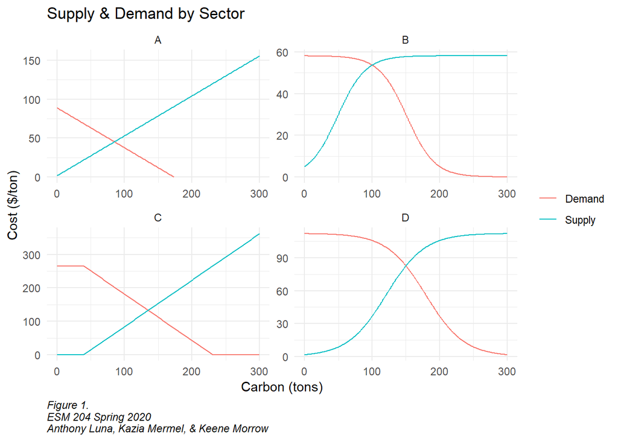

### 3.

#### a.

The cost of abatement for each sector (A, B, and C) was calculated by integrating the functions derived previously from 0 to 100 tons of carbon. Total cost was calculated as the sum of all sectors.

#### b.

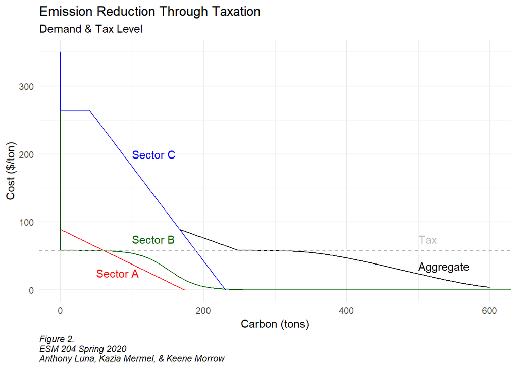

Referencing Figure 2, the tax to produce the desired reduction was calculated by expressing the functions for the sectors of interest in terms of abatement/pollution, then the price was calcualted for the appropriate abatement level (300 tons). This allowed the total cost of the tax to be calculated by integrating each sector’s function from the desired carbon emission that would be accomplished by the tax to the quantity of carbon currently emitted. The total cost of the tax was found by summing those values and the tax revenue by multiplying the tax ($57.75/ton) by the emission level (300 tons).

#### c.

Using the tax calculated above as the price to achieve a reduction of 300 tons of carbon emissions, the demand for carbon for each sector was calculated. The difference between the allocated 100 tons of carbon emissions and the demand was calculated, then used to determine the cost or benefit to each sector at their respective equilibriums The total cost of the program was calculated and found to be the same as the total cost of the tax in part b. There is no tax revenue associated with this scenario.

### 4.